# 7 Steps for setting up Apache Spark on a free (or not free) tiered Linux EC2 instance and running PySpark on a Jupyter Notebook Server that you can access on your remote machine

### Please note--- all of the resources mentioned on this document have been deleted, including the s3 bucket. Also, the keys used to log-in to my now deleted EC2 instance have been deleted. Nothing is secure; never underestimate the abilities of hackers... Finally, the cost for this project ended up being a little over a dollar. If you don't spin down your resources, etc... AWS will eventually charge you for its service.

# Step 1. Spin up a (free tier) Linux EC2 instance on AWS ; ssh into and update

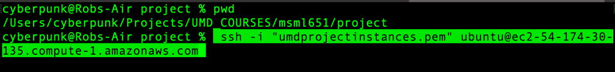

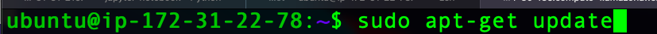

# Step 2. Go to Apache Spark's Website and install Spark on you EC2 instance

[figure not shown]

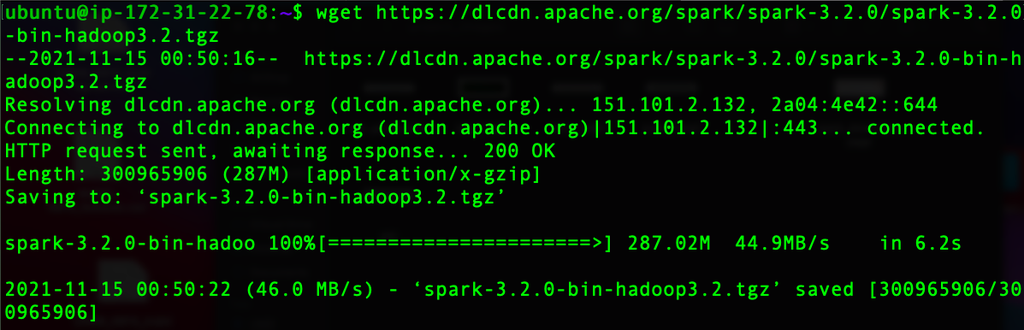

# STEP 3. Untar ; save the folder in /opt

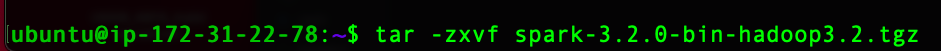

# STEP 4. Make the following installations

## A.) PIP3

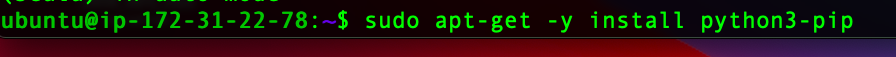

## B.) Py4J

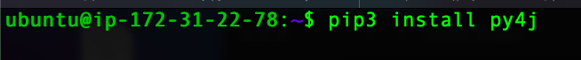

## D.) JAVA 11

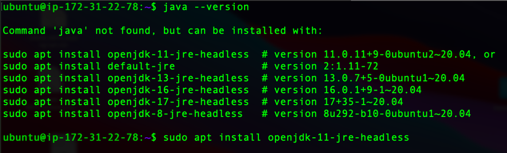

## E.) SCALA

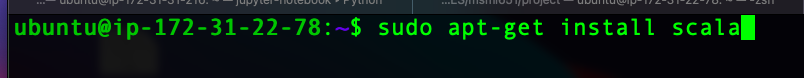

## F.) AWS Command Line

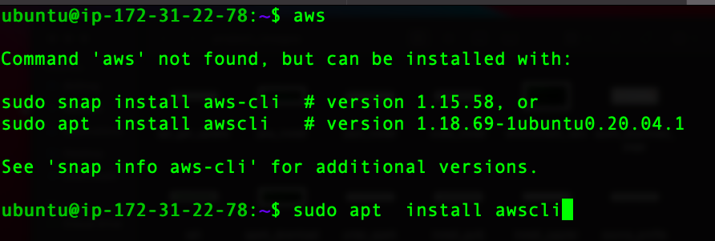

# STEP 5. Spark Configurations in ~/.profile; includes using Jupyter notebook when launching PySpark

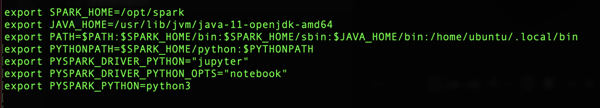

## A.) Also make sure following edits made to /opt/spark/bin/pyspark

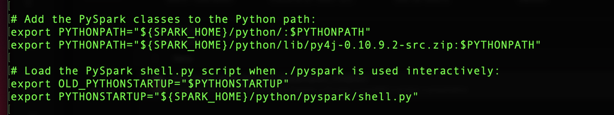

### Note: line below is last line of /opt/spark/bin/pyspark; (I used "more pyspark" on the command line to show its contents)

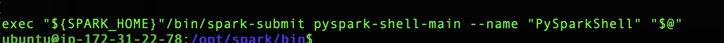

## STEP 6. Generate Jupyter config file (can be found in .jupyter folder of home directory); and make configurations as needed. Below are a few I made

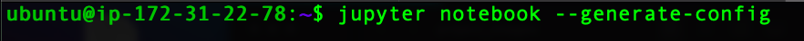

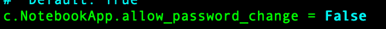

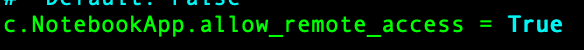

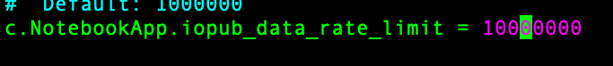

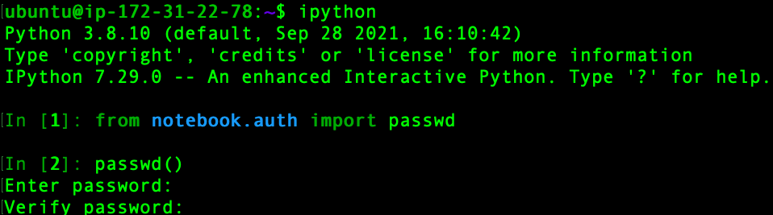

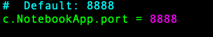

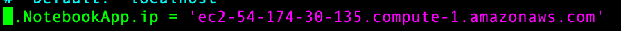

# STEP 7. Set up security group; for my project only allowed my Local, remote IP address for inbound

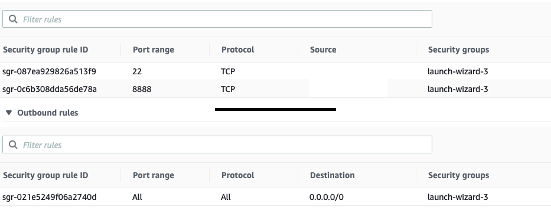

# STEP 7: START SPARK AND LOGIN FROM LOCAL MACHINE; please note, that setting up an s3 bucket and giving the EC2 instance access rights to that s3 bucket are not covered in this write-up. Here is the link that I used to do this though, if interested: https://aws.amazon.com/premiumsupport/knowledge-center/ec2-instance-access-s3-bucket/

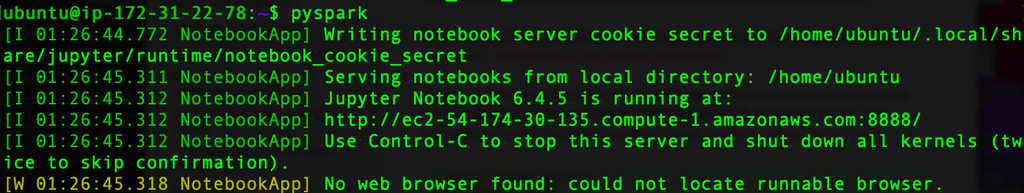

[figure not shown]

[figure not shown]